# Rates of entanglement inferred from scarring of humpback whales photographed in US Oregon waters

Solene Derville

21 mars, 2025, 09:29

# 1 Load data

Shapefiles

```r
# coastline shapefile
coast_sf <- st_read("./Inputs/coast_openstreetmap_WA-OR-CA.shp")
# isobaths
iso_sf <- st_read("./Inputs/isobaths_50mto1500m.shp")
iso_sf_utm <- st_transform(iso_sf, crs = 32610)

# 40 fathom fishing limit
iso40_sf <- st_read("./Inputs/XY40fm_03152021_PointsToLine1.shp")
iso40_sf_utm <- st_transform(iso_sf, crs = 32610)

# places names
places <- data.frame(name = c("Astoria", "Newport", "Charleston", "Brookings", "Garibaldi", "Cascade Head", "Bandon", "Winchester Bay", "Port Orford"),
                      lon = c(-123.65, -123.75,-123.97, -123.96, -123.59, -123.5, -124.15, -123.7, -124.11),
                      lat = c(46.1,  44.6, 43.3, 42.08, 45.55, 45.07, 43.12, 43.67, 42.76),
                     type = c(rep("cities", 5), rep("zones", 2), rep("cities", 2)))
places <- st_as_sf(places, coords = c("lon", "lat"), crs = 4326)
```

Inset map

```r
# US small map
northam <- ne_countries(scale = "medium", returnclass = "sf", continent = "North America") %>%
  filter(admin %in% c("United States of America", "Canada", "Mexico"))

# oregon
or <- maps::map("state", plot = F, fill = TRUE) %>%
  st_as_sf() %>%
  filter(ID == "oregon")

g <- ggplot(northam) +
  geom_sf(fill = "grey95", col = "grey30", lwd = 0.1) +
  geom_sf(data = or, fill = "lightblue", col = "grey30", lwd = 0.1) +
  coord_sf(xlim = c(-170, -68), ylim=c(20, 72)) +
  theme_void() +
  theme(panel.border = element_rect(color = "grey95", fill = "transparent", linewidth = 1))
ggsave(g, file = "./Outputs/inset_fig.png", bg = "transparent", units = "mm", width = 50, height = 40, dpi = 800)
```

Load datasets prepared as RData

```r
load("./Inputs/score_df.RData")
```

# 2 Summarize data

## 2.1 Scores per photo

Filter and change factor levels

```r
score_df <- score_df %>%
  # remove quality 4 photos
  filter(Quality != "QUA4") %>%
  # remove positions outside Oregon waters
  filter(lat >= 41.9 & lat <= 46.3) %>%
  # add a body part per side column
  mutate(Body_part_side = paste(Body_part, Side, sep = "_")) %>%
  # change the factor levels to abbreviate photo types a.k.a Body_part
  mutate(Body_part = car::recode(Body_part, "'Ventral tailstock' = 'Ventral T.'; 'Perpendicular tailstock'='Perpendicular T.';'Forward tailstock'='Forward T.'; 'Dorsal tailstock'='Dorsal T.'; 'Fluke underside' = 'Fluke'", as.numeric = F)) %>%
  mutate(Entang = factor(Entang, levels = c("ENT1-Most likely", "ENT2-Likely","ENT3-Possibly","ENT4-Unlikely"))) %>%
  filter(!(substr(ID, 1, 4) %in% c("MNOR", "NIMN")))
```

## 2.2 Scores per individual per year

### 2.2.1 Wall et al. approach

```r
#########################################
############ using left / right #########

# best quality photo of highest entang score per body part per individual per year
# for perp and forward we are selecting the best of rights and the best of the lefts
score_best_byside_df <- score_df %>%
  ddply(., .(ID, Year, Body_part_side), function(d){
    dd <- d %>%
      filter(Entang_num == min(Entang_num, na.rm = T)) %>%
      filter(Quality_num == min(Quality_num, na.rm = T))
    return(dd[1,])
  })

#########################################
############ merging left / right #######

# same thing but using the highest score of both sides for left and right
# for perpendicular and forward photos, if there is a left and a right photo it's going to pick the one with highest proba of entanglement between the two
score_best_df <- score_df %>%
  ddply(., .(ID, Year, Body_part), function(d){
    dd <- d %>%
      filter(Entang_num == min(Entang_num, na.rm = T)) %>%
      filter(Quality_num == min(Quality_num, na.rm = T))
    return(dd[1,])
  })
```

### 2.2.2 Robbins & Mattila approach

Calculate E scores based on S scores that were estimated for every region of the perpendicular or forward tailstock photos

```r
perp_df <- score_df %>%
  # select only the perpendicular and forward photo types
  filter(Body_part %in% c("Perpendicular T." , "Forward T.")) %>%
  # convert scores to numeric values
  mutate(Perp_DP = as.numeric(str_split_i(Perp_DP, "-S", 2)),
         Perp_VP = as.numeric(str_split_i(Perp_VP, "-S", 2)),
         Perp_RFlank = as.numeric(str_split_i(Perp_RFlank, "-S", 2)),
         Perp_RFluke = as.numeric(str_split_i(Perp_RFluke, "-S", 2)),
         Perp_LFlank = as.numeric(str_split_i(Perp_LFlank, "-S", 2)),
         Perp_LFluke = as.numeric(str_split_i(Perp_LFluke, "-S", 2))) %>%
  # by day and individual and body part (perp or forward), combine the scores of both sides when available
  ddply(., .(ID, Date, Body_part), function(d){
    if(nrow(d) > 1){
      left <- d %>% filter(Side == "L")
      right <- d %>% filter(Side == "R")
      dd <- d[1, ] %>%
      # use the max entang score of the two sides for the ventral and dorsal score
      mutate(Perp_DP = max(d$Perp_DP, na.rm = T),
               Perp_VP = max(d$Perp_VP, na.rm = T),
               Perp_RFlank = right$Perp_RFlank,
               Perp_LFlank = left$Perp_LFlank,
               Perp_RFluke = right$Perp_RFluke,
               Perp_LFluke = left$Perp_LFluke,
               Entang_num = min(d$Entang_num, na.rm = T),
               Quality_num = min(d$Quality_num, na.rm = T))
    } else {
      dd <- d}
    # replace -Inf by NA when max() introduced Inf
    dd <- dd %>%
      mutate(Perp_DP = ifelse(Perp_DP == -Inf, NA, Perp_DP),
             Perp_VP = ifelse(Perp_VP == -Inf, NA, Perp_VP))
    return(dd)
  })

# count the number of scores >= 1, >= 3 and >= 5
perp_df$Count_S1 <- rowSums(perp_df[, c("Perp_DP", "Perp_VP", "Perp_RFlank", "Perp_RFluke", "Perp_LFlank", "Perp_LFluke")] >= 1, na.rm = T)
perp_df$Count_S3 <- rowSums(perp_df[, c("Perp_DP", "Perp_VP", "Perp_RFlank", "Perp_RFluke", "Perp_LFlank", "Perp_LFluke")] >= 3, na.rm = T)
perp_df$Count_S5 <- rowSums(perp_df[, c("Perp_DP", "Perp_VP", "Perp_RFlank", "Perp_RFluke", "Perp_LFlank", "Perp_LFluke")] >= 5, na.rm = T)
perp_df$Count_noNA <- rowSums(!is.na(perp_df[, c("Perp_DP", "Perp_VP", "Perp_RFlank", "Perp_RFluke", "Perp_LFlank", "Perp_LFluke")]))

# convert the scar codes by region to an entanglement status code per individual and date
perp_df <- perp_df %>%
  mutate(Perp_Entang = case_when(Count_S1 == 0 ~ "E0",
                                 Count_S1 >= 1 & Count_S3 == 0 ~ "E1",
                                 Count_S3 == 1 & Count_S5 == 0 ~ "E2",
                                 Count_S3 >= 2 & Count_S5 == 0 ~ "E3",
                                 Count_S5 >= 1 ~ "E4")) %>%
  mutate(Perp_Entang = factor(Perp_Entang, levels = c("E4", "E3", "E2", "E1", "E0")),
         Perp_Entang_num = as.numeric(Perp_Entang)) %>%
  select(ID, Date, Perp_DP, Perp_VP, Perp_RFlank, Perp_RFluke, Perp_LFlank, Perp_LFluke, Perp_Entang,  Perp_Entang_num, Entang_num, Count_noNA, Year, Sex, Quality_num, lon, lat)
head(perp_df)
```

```
##         ID       Date Perp_DP Perp_VP Perp_RFlank Perp_RFluke Perp_LFlank
## 1 CRC10226 2019-08-01       1      NA          NA          NA           0
## 2 CRC10585 2017-10-16       1       0          NA          NA           0
## 3 CRC10610 2018-07-31      NA      NA          NA          NA          NA
## 4 CRC10675 2018-07-28       0       0          NA          NA           0
## 5 CRC10781 2017-09-27       4      NA          NA          NA           1
## 6 CRC11214 2020-07-09       4      NA          NA          NA           0
##   Perp_LFluke Perp_Entang Perp_Entang_num Entang_num Count_noNA Year  Sex
## 1           0          E1               4          4          3 2019    F
## 2           0          E1               4          4          4 2017    M
## 3           3          E2               3          3          1 2018 <NA>
## 4           1          E1               4          4          4 2018    M
## 5           3          E3               2          1          3 2017    M
## 6           1          E2               3          3          3 2020    M
##   Quality_num       lon      lat
## 1           2 -124.7608 42.99240
## 2           2 -124.4502 44.68607
## 3           3 -124.3087 43.79800
## 4           1 -125.0329 44.82000
## 5           2 -124.5580 41.97711
## 6           2 -124.2677 44.04130
```

```r
perp_best_df <- perp_df %>%
  ddply(., .(ID, Year), function(d){
    dd <- d %>%
      filter(Perp_Entang_num == min(Perp_Entang_num, na.rm = T))
    return(dd[1,])
  })
```

## 2.3 Scores per individual

### 2.3.1 Wall et al. approach

```r
#########################################
############ using left / right #########

# best quality photo of highest entang score per body part per individual
score_bestid_byside_df <- score_df %>%
  ddply(., .(ID, Body_part_side), function(d){
    dd <- d %>%
      filter(Entang_num == min(Entang_num, na.rm = T)) %>%
      filter(Quality_num == min(Quality_num, na.rm = T))
    return(dd[1,])
  })

#########################################
############ merging left / right #######

score_bestid_df <- score_df %>%
  ddply(., .(ID, Body_part), function(d){
    dd <- d %>%
      filter(Entang_num == min(Entang_num, na.rm = T)) %>%
      filter(Quality_num == min(Quality_num, na.rm = T))
    return(dd[1,])
  })
```

### 2.3.2 Robbins & Mattila approach

```r
perp_bestid_df <- perp_best_df %>%
  ddply(., ~ID, function(d){
    dd <- d %>%
      filter(Perp_Entang_num == min(Perp_Entang_num, na.rm = T)) %>%
      filter(Quality_num == min(Quality_num, na.rm = T))
    return(dd[1,])
  })
```

# 3 Overall numbers and descriptive stats

## 3.1 Describe dataset

```r
# total number of photos after filtering out the bad quality
nrow(score_df)
```

```
## [1] 1533
```

```r
# contributions of collaborators
# in photos
table(score_df$Source)
```

```
##
##     SOURCE-CRC SOURCE-GEMMLAB  SOURCE-NEWELL SOURCE-WHETLAB
##            950            358              6            219
```

```r
# in individuals
score_df %>%
  group_by(Source) %>%
  summarize(ind = n_distinct(ID))
```

```
## # A tibble: 4 × 2
##   Source           ind
##   <chr>          <int>
## 1 SOURCE-CRC       403
## 2 SOURCE-GEMMLAB   145
## 3 SOURCE-NEWELL      2
## 4 SOURCE-WHETLAB    81
```

```r
# number of photos contributed by fishermen
length(str_subset(score_df$file, ".CBarnhart")) + length(str_subset(score_df$file, ".Josh"))
```

```
## [1] 24
```

```r
score_df %>%
  filter(file %in% c(str_subset(score_df$file, ".CBarnhart"),
                     str_subset(score_df$file, ".Josh"))) %>%
  summarize(ind = n_distinct(ID))
```

```
##   ind
## 1  10
```

```r
# individuals photographed by OSU, excluding fishermen photos
score_df %>%
  filter(!(file %in% c(str_subset(score_df$file, ".CBarnhart"),
                     str_subset(score_df$file, ".Josh"))) &
             Source %in% c("SOURCE-GEMMLAB", "SOURCE-WHETLAB")) %>%
  summarize(ind = n_distinct(ID))
```

```
##   ind
## 1 208
```

```r
# how many new cases of entang ind?
d <- score_df %>%
  filter(file %in% c(str_subset(score_df$file, ".CBarnhart"),
                     str_subset(score_df$file, ".Josh")),
         Entang == "ENT1-Most likely")
score_df[score_df$ID %in% unique(d$ID),]
```

```
##            ID       Date                              file Quality  Body_part
## 1096 CRC30008 2023-08-28 20230828_SLATE_CBarnhart_2059.JPG    QUA2 Forward T.
## 1097 CRC30008 2023-08-28 20230828_SLATE_CBarnhart_2074.JPG    QUA2  Dorsal T.
## 1098 CRC30008 2023-08-28 20230828_SLATE_CBarnhart_2083.JPG    QUA2      Fluke
##                Entang Fresh Perp_DP Perp_VP Perp_RFlank Perp_RFluke Perp_LFlank
## 1096 ENT1-Most likely     0   DP-S5    <NA>        <NA>   RFluke-S5        <NA>
## 1097    ENT4-Unlikely     0    <NA>    <NA>        <NA>        <NA>        <NA>
## 1098    ENT4-Unlikely     0    <NA>    <NA>        <NA>        <NA>        <NA>
##      Perp_LFluke Mirrored_notches Fluke_abovewater Year         Source Side
## 1096   LFluke-S5                0                0 2023 SOURCE-GEMMLAB    R
## 1097        <NA>                0                0 2023 SOURCE-GEMMLAB <NA>
## 1098        <NA>                0                1 2023 SOURCE-GEMMLAB <NA>
##      Quality_num Entang_num       lon      lat    Vessel  Sex dlphap
## 1096           2          1 -124.4862 43.90033 Dauntless <NA>   <NA>
## 1097           2          4 -124.4862 43.90033 Dauntless <NA>   <NA>
## 1098           2          4 -124.4862 43.90033 Dauntless <NA>   <NA>
##           Body_part_side
## 1096 Forward tailstock_R
## 1097 Dorsal tailstock_NA
## 1098  Fluke underside_NA
```

```r
# how many unique IDs in Wall et al. approach
n_distinct(score_best_df$ID)
```

```
## [1] 571
```

```r
# how many unique IDs in Robbins & Mattila approach
n_distinct(perp_best_df$ID)
```

```
## [1] 121
```

```r
# how many year x IDs = encounters after removing within season resights
n_distinct(paste0(score_best_df$ID, score_best_df$Year))
```

```
## [1] 646
```

```r
# how many real unique IDs (not the NI)
score_best_df %>%
  filter(!(substr(ID, 1, 4) %in% c("MNOR", "NIMN"))) %>%
  summarize(unique_photoID = n_distinct(ID))
```

```
##   unique_photoID
## 1            571
```

```r
# how many real unique IDs identified with Most likely entang
score_best_df %>%
  filter(!(substr(ID, 1, 4) %in% c("MNOR", "NIMN"))) %>%
  filter(Entang_num == 1) %>%
  summarize(unique_photoID_ENT1 = n_distinct(ID))
```

```
##   unique_photoID_ENT1
## 1                  47
```

```r
# average number of body parts per whales per season
a <- score_best_df %>%
  group_by(ID, Year) %>%
  summarize(nb_body_parts = n_distinct(Body_part))
```

```
## argument.
```

```r
mean(a$nb_body_parts)
```

```
## [1] 2.143963
```

```r
sd(a$nb_body_parts)
```

```
## [1] 0.9544766
```

```r
# average number of body parts per whales per season, not combining left and right
a <- score_best_byside_df %>%
  group_by(ID, Year) %>%
  summarize(nb_body_parts = n_distinct(Body_part_side))
```

```
## argument.
```

```r
mean(a$nb_body_parts)
```

```
## [1] 2.159443
```

```r
sd(a$nb_body_parts)
```

```
## [1] 0.9871872
```

```r
# average number of body parts per whales per season of quality 1
a <- score_best_df %>%
  filter(Quality == "QUA1") %>%
  group_by(ID, Year) %>%
  summarize(nb_body_parts = n_distinct(Body_part))
```

```
## argument.
```

```r
mean(a$nb_body_parts)
```

```
## [1] 1.322709
```

```r
sd(a$nb_body_parts)
```

```
## [1] 0.5894423
```

```r
# and considering left and right
a <- score_best_byside_df %>%
  filter(Quality == "QUA1") %>%
  group_by(ID, Year) %>%
  summarize(nb_body_parts = n_distinct(Body_part_side))
```

```
## argument.
```

```r
mean(a$nb_body_parts)
```

```
## [1] 1.329365
```

```r
sd(a$nb_body_parts)
```

```
## [1] 0.6108667
```

```r
# total number of body parts photographed
score_best_df %>%
  group_by(Body_part) %>%
  summarize(nb_photos= n())
```

```
## # A tibble: 5 × 2
##   Body_part        nb_photos
##   <chr>                <int>
## 1 Dorsal T.              325
## 2 Fluke                  619
## 3 Forward T.              17
## 4 Perpendicular T.       113
## 5 Ventral T.             311
```

```r
# how many males and females
score_bestid_df %>%
  group_by(ID) %>%
  summarize(Sex = Sex[1]) %>%
  group_by(Sex) %>%
  summarize(n = n())
```

```
## # A tibble: 3 × 2
##   Sex       n
##   <chr> <int>
## 1 F        54
## 2 M        80
## 3 <NA>    437
```

```r
# percent photos collected after 2016
score_best_df %>%
  mutate(cut2016 = ifelse(as.numeric(as.character(Year)) >= 2016, "post", "prior")) %>%
  group_by(cut2016) %>%
  summarize(n = n()) %>%
  mutate(percent = round(n / sum(n)*100, 1))
```

```
## # A tibble: 2 × 3
##   cut2016     n percent
##   <chr>   <int>   <dbl>
## 1 post     1362    98.3
## 2 prior      23     1.7
```

```r
# annual cases of raw scars
score_best_df %>%
  filter(Fresh == 1) %>%
  summarize(ind = n_distinct(ID))
```

```
##   ind
## 1  15
```

```r
# overall number of ind with most likely entang (all body parts combined)
score_bestid_df %>%
  filter(Entang_num == 1) %>%
  summarize(nb_ID = n_distinct(ID)) %>%
  pull(nb_ID)
```

```
## [1] 47
```

```r
# overall number of ind with most likely or likely entang (all body parts combined)
score_bestid_df %>%
  filter(Entang_num <= 2) %>%
  summarize(nb_ID = n_distinct(ID)) %>%
  pull(nb_ID)
```

```
## [1] 109
```

## 3.2 Table of sample size per quality and photo type

```r
quality_wall <- score_best_df %>%
  group_by(Body_part, Quality, .drop = FALSE) %>%
  summarize(n = n()) %>%
  mutate(percent = round(n / sum(n)*100, 1)) %>%
  mutate(nb = paste0(percent, " (",n,")")) %>%
  select(-c(n, percent)) %>%
  pivot_wider(names_from = Quality, values_from = nb) %>%
  rename("Photo type" = "Body_part")
quality_robbins <- perp_best_df %>%
  mutate(Quality = paste0("QUA", Quality_num)) %>%
  group_by(Quality, .drop = FALSE) %>%
  summarize(n = n()) %>%
  mutate(percent = round(n / sum(n)*100, 1)) %>%
  mutate(nb = paste0(percent, " (",n,")")) %>%
  select(-c(n, percent)) %>%
  pivot_wider(names_from = Quality, values_from = nb) %>%
  mutate(`Photo type` = "Perpendicular/Forward T.") %>%
  select(`Photo type`, everything())

quality_df <- rbind(quality_wall, quality_robbins) %>%
  mutate(`Photo type` = factor(`Photo type`, levels = c('Fluke', 'Dorsal T.', 'Ventral T.', 'Perpendicular T.', 'Forward T.', 'Perpendicular/Forward T.'))) %>%
  rename("Quality 1" = "QUA1", "Quality 2" = "QUA2", "Quality 3" = "QUA3")

ft2 <- quality_df %>%
  flextable() %>%
  theme_vanilla() %>%
  align(align = "center", part = "all") %>%
  align_text_col(align = "left") %>%
  fontsize(part = "body", size = 11) %>%
  fontsize(part = "header", size = 12)
ft2
```

| Photo type | Quality 1 | Quality 2 | Quality 3 |
| --- | --- | --- | --- |
| Dorsal T. | 37.8 (123) | 43.4 (141) | 18.8 (61) |
| Fluke | 24.2 (150) | 47 (291) | 28.8 (178) |
| Forward T. | 41.2 (7) | 52.9 (9) | 5.9 (1) |
| Perpendicular T. | 16.8 (19) | 59.3 (67) | 23.9 (27) |
| Ventral T. | 10.6 (33) | 44.4 (138) | 45 (140) |
| Perpendicular/Forward T. | 20.8 (26) | 56.8 (71) | 22.4 (28) |

```r
ft2 %>% save_as_docx(path = "./Outputs/Table2.docx")

## associated x2 test
# convert format to apply chisq test on frequencies
tt <- table(score_best_df$Body_part, score_best_df$Quality, dnn = c("Body part", "Quality"))
tt
```

```
##                   Quality
## Body part          QUA1 QUA2 QUA3
##   Dorsal T.         123  141   61
##   Fluke             150  291  178
##   Forward T.          7    9    1
##   Perpendicular T.   19   67   27
##   Ventral T.         33  138  140
```

```r
######### Chisq test of independence
## Ordinal Chi-square test using permutations (coin library)
coin::chisq_test(tt, scores = list("Quality" = c(-1, 0, 1)))
```

```
##
##  Asymptotic Generalized Pearson Chi-Squared Test
##
## data:  Quality (ordered) by
##   Body.part (Dorsal T., Fluke, Forward T., Perpendicular T., Ventral T.)
## chi-squared = 91.456, df = 4, p-value < 2.2e-16
```

```r
# post-hoc
PT <- rcompanion::pairwiseOrdinalIndependence(tt, compare = "row", method = "bonferroni")
PT
```

```
##                       Comparison  p.value p.adjust
## 1              Dorsal T. : Fluke 2.82e-06 2.82e-05
## 2         Dorsal T. : Forward T. 3.67e-01 1.00e+00
## 3   Dorsal T. : Perpendicular T. 7.96e-04 7.96e-03
## 4         Dorsal T. : Ventral T. 1.57e-19 1.57e-18
## 5             Fluke : Forward T. 2.57e-02 2.57e-01
## 6       Fluke : Perpendicular T. 7.26e-01 1.00e+00
## 7             Fluke : Ventral T. 2.29e-09 2.29e-08
## 8  Forward T. : Perpendicular T. 1.15e-02 1.15e-01
## 9        Forward T. : Ventral T. 3.48e-05 3.48e-04
## 10 Perpendicular T. : Ventral T. 1.86e-04 1.86e-03
```

```r
# average percent of quality 1 across photo types of wall et al
score_best_df %>%
  group_by(Body_part, Quality, .drop = FALSE) %>%
  summarize(n = n()) %>%
  mutate(percent = round(n / sum(n)*100, 1)) %>%
  select(-c(n)) %>%
  filter(Quality == "QUA1") %>%
  pull(percent) %>% mean()
```

```
## [1] 26.12
```

## 3.3 Table of scarring prevalence per approach

```r
df_wall <- score_bestid_df %>%
  mutate(Body_part = factor(Body_part, levels = c('Fluke', 'Dorsal T.', 'Ventral T.', 'Perpendicular T.', 'Forward T.'))) %>%
  group_by(Body_part, Entang, .drop = FALSE) %>%
  mutate(Entang = car::recode(as.character(Entang), "'ENT1-Most likely' = 'Most likely'; 'ENT2-Likely' = 'Likely'; 'ENT4-Unlikely' = 'Unlikely' ;'ENT3-Possibly' = 'Possibly'", as.numeric = F)) %>%
  mutate(Entang = factor(Entang, levels = c("Most likely", "Likely", "Possibly", "Unlikely"))) %>%
  summarize(n = n()) %>%
  mutate(percent = round(n / sum(n)*100, 1)) %>%
  mutate(nb = paste0(percent, " (",n,")")) %>%
  select(-c(n, percent)) %>%
  pivot_wider(names_from = Entang, values_from = nb) %>%
  rename("Photo type" = "Body_part")
df_robbins <- perp_bestid_df %>%
  group_by(Perp_Entang, .drop = FALSE) %>%
  summarize(n = n()) %>%
  mutate(percent = round(n / sum(n)*100, 1)) %>%
  mutate(nb = paste0(percent, " (",n,")")) %>%
  select(-c(n, percent)) %>%
  pivot_wider(names_from = Perp_Entang, values_from = nb) %>%
  mutate(`Photo type` = "Perpendicular/Forward T.") %>%
  select(`Photo type`, everything())

ft3a <- df_wall %>%
  flextable() %>%
  add_header_row(values = c("", "Likelihood of prior entanglement"), colwidths = c(1, 4)) %>%
  theme_vanilla() %>%
  align(align = "center", part = "all") %>%
  align_text_col(align = "left") %>%
  fontsize(part = "body", size = 11) %>%
  fontsize(part = "header", size = 12)
ft3a
```

| Photo type | Likelihood of prior entanglement Most likely | Likelihood of prior entanglement Likely | Likelihood of prior entanglement Possibly | Likelihood of prior entanglement Unlikely |
| --- | --- | --- | --- | --- |
| Fluke | 2.2 (12) | 4.2 (23) | 18.4 (101) | 75.2 (412) |
| Dorsal T. | 5.3 (16) | 7.6 (23) | 15.5 (47) | 71.7 (218) |
| Ventral T. | 4.8 (14) | 9.9 (29) | 17.8 (52) | 67.5 (197) |
| Perpendicular T. | 19.1 (21) | 19.1 (21) | 26.4 (29) | 35.5 (39) |
| Forward T. | 17.6 (3) | 5.9 (1) | 35.3 (6) | 41.2 (7) |

```r
ft3a %>% save_as_docx( path = "./Outputs/Table3a.docx")

ft3b <- df_robbins %>%
  flextable() %>%
  theme_vanilla() %>%
  align(align = "center", part = "all") %>%
  align_text_col(align = "left") %>%
  fontsize(part = "body", size = 11) %>%
  fontsize(part = "header", size = 12)
ft3b
```

| Photo type | E4 | E3 | E2 | E1 | E0 |
| --- | --- | --- | --- | --- | --- |
| Perpendicular/Forward T. | 6.6 (8) | 20.7 (25) | 17.4 (21) | 46.3 (56) | 9.1 (11) |

```r
ft3b %>% save_as_docx( path = "./Outputs/Table3b.docx")
```

## 3.4 Main indicators of scarring prevalence

Function to calculate confidence interval on scarring prevalence estimates

```r
Fun_ConfInt <- function(p,n){
  conf_low <- p - 1.96*sqrt((p * (100-p))/n)
  conf_high <- p + 1.96*sqrt((p * (100-p))/n)
  return(c(conf_low, conf_high))
}
```

### 3.4.1 Wall et al. Most likely proportion

The percent of individuals showing “Most likely” entanglement scars in either of the five possible photo types is presented following the Wall et al. (2019) approach.

```r
tot_wall_df <- score_bestid_df %>%
  group_by(ID) %>%
  summarize(Entang_num = min(Entang_num))

# number of individuals considered
(Ntot_wall <- nrow(tot_wall_df))
```

```
## [1] 571
```

```r
# number of individuals with at least one body part showing “Most likely” and “Likely” entanglement scars
Ent_wallm <- tot_wall_df %>% filter(Entang_num <= 1)
(Nent_wallm <- nrow(Ent_wallm))
```

```
## [1] 47
```

```r
# proportion of individuals with at least one body part showing “Most likely” and “Likely”
(Pwallm <- Nent_wallm / Ntot_wall*100)
```

```
## [1] 8.231173
```

```r
# confidence interval
Fun_ConfInt(Pwallm, Ntot_wall)
```

```
## [1]  5.976849 10.485498
```

Check that the results are similar if the Pwallm was calculated only with 2016-2023 data so as to cover the same time period as Prob

```r
tot_wall_df_2016 <- score_bestid_df %>%
  filter(as.numeric(Year) >= 2016) %>%
  group_by(ID) %>%
  summarize(Entang_num = min(Entang_num))

# number of individuals considered
(Ntot_wall16 <- nrow(tot_wall_df_2016))
```

```
## [1] 555
```

```r
# number of individuals with at least one body part showing “Most likely” and “Likely” entanglement scars
Ent_wallm16 <- tot_wall_df_2016 %>% filter(Entang_num <= 1)
(Nent_wallm16 <- nrow(Ent_wallm16))
```

```
## [1] 47
```

```r
# proportion of individuals with at least one body part showing “Most likely” and “Likely”
(Pwallm16 <- Nent_wallm16 / Ntot_wall16*100)
```

```
## [1] 8.468468
```

```r
# confidence interval
Fun_ConfInt(Pwallm16, Ntot_wall16)
```

```
## [1]  6.152155 10.784782
```

### 3.4.2 Wall et al. Most likely + likely proportion

The percent of individuals showing “Most likely” and “Likely” entanglement scars in either of the five possible photo types is presented following the Wall et al. (2019) approach.

```r
tot_wall_df <- score_bestid_df %>%
  group_by(ID) %>%
  summarize(Entang_num = min(Entang_num))

# number of individuals considered
(Ntot_wall <- nrow(tot_wall_df))
```

```
## [1] 571
```

```r
# number of individuals with at least one body part showing “Most likely” and “Likely” entanglement scars
Ent_wall <- tot_wall_df %>% filter(Entang_num <= 2)
(Nent_wall <- nrow(Ent_wall))
```

```
## [1] 109
```

```r
# proportion of individuals with at least one body part showing “Most likely” and “Likely”
(Pwall <- Nent_wall / Ntot_wall*100)
```

```
## [1] 19.08932
```

```r
# confidence interval
Fun_ConfInt(Pwall, Ntot_wall)
```

```
## [1] 15.86575 22.31288
```

### 3.4.3 Robbins & Mattila approach E4 and E3 proportion

The percent of individuals showing E4 and E3 status in either their perpendicular or forward tailstock photos is presented following the Robbins & Mattila (2001) approach.

```r
tot_robbins_df <- perp_bestid_df %>%
  group_by(ID) %>%
  summarize(Entang_num = min(Perp_Entang_num))

# number of individuals considered
(Ntot_rob <- nrow(tot_robbins_df))
```

```
## [1] 121
```

```r
# number of individuals with at least one body part showing “Most likely” and “Likely” entanglement scars
Ent_rob <- tot_robbins_df %>% filter(Entang_num <= 2)
(Nent_rob <- nrow(Ent_rob))
```

```
## [1] 33
```

```r
# proportion of individuals with at least one body part showing “Most likely” and “Likely”
(Prob <- Nent_rob / Ntot_rob*100)
```

```
## [1] 27.27273
```

```r
# confidence interval
Fun_ConfInt(Prob, Ntot_rob)
```

```
## [1] 19.33719 35.20826
```

### 3.4.4 Added value of analyzing fluke photos

To investigate the added value of analyzing fluke photos compared to the typical perpendicular tailstock photos used by Robbins & Mattila (2001), we further report the number of individuals whose fluke photos were assigned a “Most likely” or “Likely” category while their perpendicular, and forward tailstock photos were either unavailable or assigned “Possible” or “Unlikely” categories.

```r
# for each individual in the dataset
flukedetections <- ddply(score_bestid_df, .(ID), function(d){
  # if there is a fluke photo and it shows a score >= Likely
  if(nrow(d[d$Entang_num <= 2 & d$Body_part %in% c("Fluke"), ]) > 0 ){
    # and if none of the other body parts showed a score >= Likely
    if(nrow(d[d$Entang_num <= 2 & d$Body_part %in% c("Perpendicular T.", "Forward T.", "Dorsal T.", "Ventral T."), ]) == 0){
    # then return the reference of this fluke photo
      return(d[(d$Entang_num <= 2 & d$Body_part %in% c("Fluke")), ])
    }
  }
})

# number of individuals whose likely or most likely score was detected only based on the fluke photo
n_distinct(flukedetections$ID)
```

```
## [1] 16
```

```r
# compare this number to the number of individuals identified as >= likely with all body parts
n_distinct(flukedetections$ID) * 100 / Nent_wall
```

```
## [1] 14.6789
```

```r
# did the whale have photos of other body parts or not?
score_bestid_df %>% filter(ID %in% unique(flukedetections$ID))
```

```
##          ID       Date                                file Quality
## 1  CRC11710 2020-09-17               20200917-JAC-0176.JPG    QUA2
## 2  CRC12008 2020-09-20      20200920_GEMM_Lab_CM3_0236.JPG    QUA2
## 3  CRC12008 2018-07-31               20180731-JAC-0059.JPG    QUA3
## 4  CRC13750 2018-09-08                   MnORa18-4577.jpeg    QUA1
## 5  CRC13750 2018-09-08                   MnORa18-4579.jpeg    QUA3
## 6  CRC15685 2018-09-24         GEMM_STEM_20180924_0056.JPG    QUA3
## 7  CRC16668 2019-09-13 20190913-OSU-STEM-Cam1_BE8A0536.JPG    QUA1
## 8  CRC16668 2019-09-13 20190913-OSU-STEM-Cam1_BE8A0535.JPG    QUA2
## 9  CRC16857 2018-07-31               20180731-KRF-0638.JPG    QUA1
## 10 CRC16857 2018-07-31               20180731-KRF-0637.JPG    QUA3
## 11 CRC17031 2018-07-31               20180731-KRF-0184.JPG    QUA1
## 12 CRC17031 2018-07-30           20180730-KRF-D32-0118.JPG    QUA3
## 13 CRC17283 2018-07-31               20180731-LGT_0810.JPG    QUA2
## 14 CRC17290 2018-07-31               20180731-JWP-7257.JPG    QUA2
```

[output cut: 130 more lines]

But flukes also often show false negatives…

```r
# Most likely scores detected via any body part but fluke and for which fluke was unlikely/possibly
mostlikely_indnoflukes <- ddply(score_bestid_df, .(ID), function(d){
  if(nrow(d[d$Entang_num == 1 & d$Body_part %in% c("Perpendicular T.", "Forward T.", "Dorsal T.", "Ventral T."), ]) > 0){
    if(nrow(d[d$Entang_num <= 2 & d$Body_part %in% c("Fluke"), ]) == 0 ){
      return(d[d$Body_part %in% c("Fluke"), ])
    }
  }
})

# number of individuals with at least one body part showing “Most likely” entanglement scars
Ent_most_wall <- tot_wall_df %>% filter(Entang_num == 1)
(Nent_most_wall <- nrow(Ent_most_wall))
```

```
## [1] 47
```

```r
# number of individuals classified as most likely based on anything but fluke
n_distinct(mostlikely_indnoflukes$ID)
```

```
## [1] 27
```

```r
# percent of most likely individuals who were discovered to be entangled on anything but fluke
n_distinct(mostlikely_indnoflukes$ID) * 100 / Nent_most_wall
```

```
## [1] 57.44681
```

```r
# example for figure S5
score_bestid_df %>% filter(ID == "CRC12174")
```

```
##         ID       Date                  file Quality  Body_part           Entang
## 1 CRC12174 2018-07-31 20180731-JAC-0259.JPG    QUA1  Dorsal T. ENT1-Most likely
## 2 CRC12174 2018-07-31 20180731-JAC-0262.JPG    QUA1      Fluke    ENT4-Unlikely
## 3 CRC12174 2018-07-31 20180731-JAC-0261.JPG    QUA2 Ventral T.    ENT4-Unlikely
##   Fresh Perp_DP Perp_VP Perp_RFlank Perp_RFluke Perp_LFlank Perp_LFluke
## 1     0    <NA>    <NA>        <NA>        <NA>        <NA>        <NA>
## 2     0    <NA>    <NA>        <NA>        <NA>        <NA>        <NA>
## 3     0    <NA>    <NA>        <NA>        <NA>        <NA>        <NA>
##   Mirrored_notches Fluke_abovewater Year     Source Side Quality_num Entang_num
## 1                0                0 2018 SOURCE-CRC <NA>           1          1
## 2                0                0 2018 SOURCE-CRC <NA>           1          4
## 3                0                0 2018 SOURCE-CRC <NA>           2          4
##        lon     lat Vessel  Sex dlphap       Body_part_side
## 1 -124.427 43.6499   <NA> <NA>   <NA>  Dorsal tailstock_NA
## 2 -124.427 43.6499   <NA> <NA>   <NA>   Fluke underside_NA
## 3 -124.427 43.6499   <NA> <NA>   <NA> Ventral tailstock_NA
```

Proportion of fluke photos where 90% of the leading edge of the fluke is visible

```r
# this considerably affects the capacity to detect scarring on the leading edge
score_df %>%
  filter(Body_part == "Fluke") %>%
  group_by(Fluke_abovewater) %>%
  summarize(nb_photos = n()) %>%
  mutate(percent = round(nb_photos / sum(nb_photos)*100, 1))
```

```
## # A tibble: 2 × 3
##   Fluke_abovewater nb_photos percent
##              <dbl>     <int>   <dbl>
## 1                0       434    61.3
## 2                1       274    38.7
```

### 3.4.5 Shigh - Slow

The highest and lowest estimates of scarring prevalence (Shigh - Slow) was highlighted among these different estimates.

```r
(Slow <- min(Prob, Pwall, Pwallm))
```

```
## [1] 8.231173
```

```r
(Shigh <- max(Prob, Pwall, Pwallm))
```

```
## [1] 27.27273
```

Compare Shigh and Slow statistically with a Fisher exact test for count data

```r
(bin_prev <- rbind(c(Nent_rob, Ntot_rob-Nent_rob), c(Nent_wallm, Ntot_wall-Nent_wallm)))
```

```
##      [,1] [,2]
## [1,]   33   88
## [2,]   47  524
```

```r
fisher.test(bin_prev)
```

```
##
##  Fisher's Exact Test for Count Data
##
## data:  bin_prev
## p-value = 6.717e-08
## alternative hypothesis: true odds ratio is not equal to 1
## 95 percent confidence interval:
##  2.443975 7.064624
## sample estimates:
## odds ratio
##   4.169185
```

```r
# check that results are the same if we focus on 2016-2023
(bin_prev <- rbind(c(Nent_rob, Ntot_rob-Nent_rob), c(Nent_wallm16, Ntot_wall16-Nent_wallm16)))
```

```
##      [,1] [,2]
## [1,]   33   88
## [2,]   47  508
```

```r
fisher.test(bin_prev)
```

```
##
##  Fisher's Exact Test for Count Data
##
## data:  bin_prev
## p-value = 1.689e-07
## alternative hypothesis: true odds ratio is not equal to 1
## 95 percent confidence interval:
##  2.368855 6.852889
## sample estimates:
## odds ratio
##   4.041953
```

# 4 Spatio-temporal effects analysis

## 4.1 Map

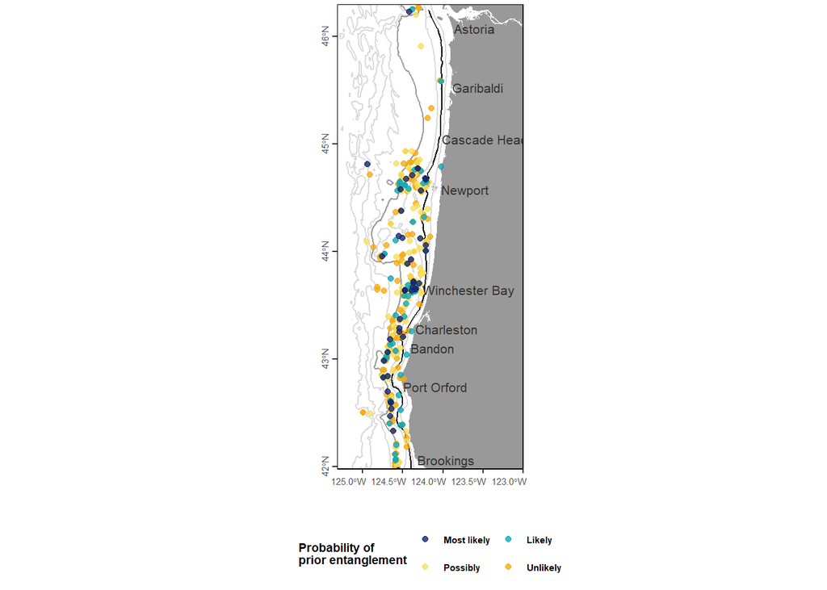

```r
score_sf <- score_best_df %>%
  group_by(ID) %>%
  summarize(Entang_num = min(Entang_num),
            lat = mean(lat, na.rm = T),
            lon = mean(lon, na.rm = T)) %>%
  mutate(Entang = car::recode(as.character(Entang_num), "'1' = 'Most likely'; '2' = 'Likely' ;'3' = 'Possibly'; '4' = 'Unlikely'", as.numeric = F)) %>%
  mutate(Entang = factor(Entang, levels = c("Most likely", "Likely", "Possibly", "Unlikely"))) %>%
  st_as_sf(coords = c("lon", "lat"), crs = 4326) %>%
  st_transform(crs = 32610) %>%
  arrange(-Entang_num)

g <- ggplot() +
    geom_sf(data = iso_sf_utm[iso_sf_utm$g_2020_ %in% c(-50, -100, -500, -1000, -1500), ], col = "grey85", size = 0.01) +
    geom_sf(data = iso_sf_utm[iso_sf_utm$g_2020_ %in% c(-200), ], col = "grey60", size = 0.08) +
    geom_sf(data = coast_sf, col = NA, fill = "grey60", size = 0.08) +
    geom_sf(data = iso40_sf, col = "black") +
    geom_sf_text(data = places, aes(label = name), nudge_x = 0, size = 2.8, col = "grey20") +
    mon_theme +
    xlab("") +
    ylab("") +
    theme(axis.text.y = element_text(angle = 90, hjust = 0.5),
        axis.text.x = element_text(hjust = 0.9),
          panel.grid = element_blank(),
          legend.position = "bottom",
          text=element_text(face="bold", size=7),
          legend.key.size = unit(0.8, "lines"),
                panel.spacing = unit(0.5, "lines"),
                plot.margin = unit(c(0.1, 0.1, 0.1, 0.1), "cm")) +
    geom_sf(data = score_sf, aes(color = Entang), alpha = 0.8) +
    coord_sf(xlim = c(307857.5, 5e+05), ylim = c(4649776, 5129996), expand = F) +
    scale_color_manual(name = "Probability of \nprior entanglement",
                    values = pal_wall) +
  guides(color=guide_legend(nrow=2, byrow=TRUE))
g
```

```r
ggsave(g, file = "./Outputs/Fig1.png", width = 90, height = 200, units = "mm", dpi = 600)
```

## 4.2 Scar scores through time

Number of photos per photo type per year

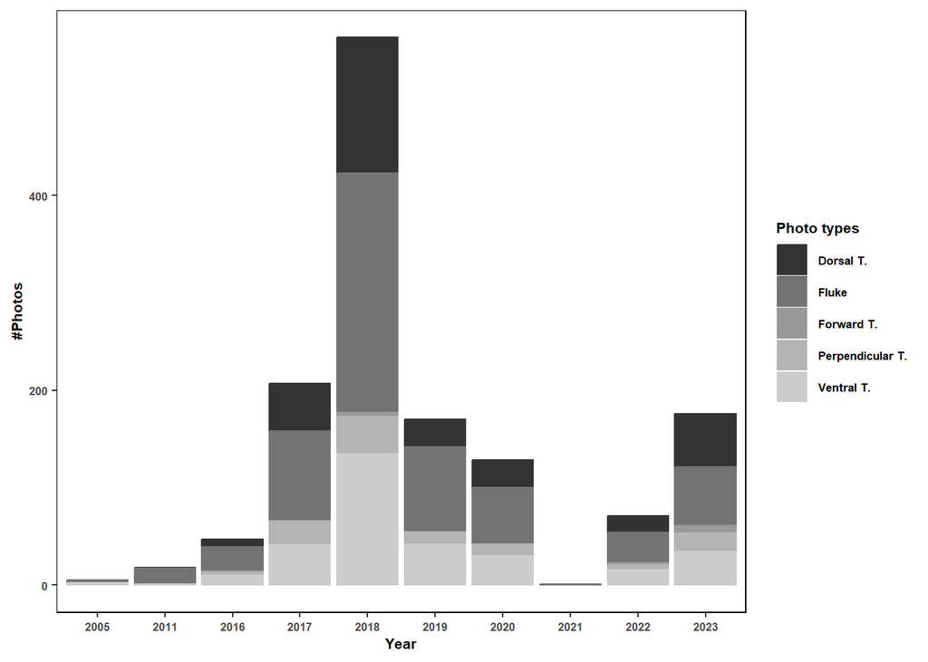

```r
g <- ggplot(score_best_df, aes(as.factor(Year), fill = Body_part, color = Body_part)) +
  geom_bar() +
  scale_fill_grey(name = "Photo types") +
  scale_color_grey(name = "Photo types") +
  mon_theme +
  xlab("Year") +
  ylab("#Photos")
g
```

```r
ggsave(g, file = "./Outputs/FigS4.png", width = 180, height = 80, units = "mm", dpi = 600)
# sample size in this plot
nrow(score_best_df)
```

```
## [1] 1385
```

```r
n_distinct(score_best_df$ID)
```

```
## [1] 571
```

Scarring prevalence per year per approach

```r
### Wall scores
# scores per year per body part
wall_year <- score_best_df %>%
  mutate(Entang = car::recode(as.character(Entang), "'ENT1-Most likely' = 'Most likely'; 'ENT2-Likely' = 'Likely'; 'ENT4-Unlikely' = 'Unlikely' ;'ENT3-Possibly' = 'Possibly'", as.numeric = F)) %>%
  mutate(Entang = factor(Entang, levels = c("Most likely", "Likely", "Possibly", "Unlikely"))) %>%
  mutate(Body_part = factor(Body_part, levels = c('Fluke', 'Dorsal T.', 'Ventral T.', 'Perpendicular T.', 'Forward T.'))) %>%
  filter(as.numeric(Year) >= 2016 & Year != "2021") %>%
  group_by(Body_part, Year, Entang, .drop = FALSE) %>%
  summarize(n = n()) %>%
  mutate(percent = round(n / sum(n)*100, 0)) %>%
  arrange(Body_part, Year, Entang)
# sample size per year
wall_year_n <- score_best_df %>%
  filter(as.numeric(Year) >= 2016 & Year != "2021") %>%
  mutate(Body_part = factor(Body_part, levels = c('Fluke', 'Dorsal T.', 'Ventral T.', 'Perpendicular T.', 'Forward T.'))) %>%
  group_by(Body_part, Year) %>%
  summarize(n = n()) %>%
  mutate(Entang = "Most likely") # dummy variable
### Robbins et al scores
# scores per year
robbins_year <- perp_best_df %>%
  group_by(Year, Perp_Entang, .drop = FALSE) %>%
  summarize(n = n()) %>%
  mutate(percent = round(n / sum(n)*100, 0)) %>%
  arrange(Year, Perp_Entang) %>%
  mutate(Body_part = "Perpendicular/Forward T.")
```

```r
# sample size per year
robbins_year_n <- perp_best_df %>%
  mutate(Body_part = "Perpendicular/Forward T.") %>%
  group_by(Year) %>%
  summarize(n = n()) %>%
  mutate(Perp_Entang = "E4") # dummy variable

### combine plots
g1 <- ggplot(wall_year,
            aes(x=Year, y=percent, fill=Entang)) +
  geom_bar(stat="identity", alpha = 0.8) +
  geom_text(data = wall_year_n, aes(x = Year, y=108, label = n, size = 2.2), col = "grey9", size = 1.8) +
  scale_fill_manual(name = "Probability of \nprior entanglement",
                    values =  pal_wall) +
  facet_wrap(~Body_part, ncol = 1) +
  mon_theme +
  ylab("Proportion of individuals (%)") +
  xlab("Year") &
  scale_y_continuous(expand = c(0,0),
                     breaks = c(25, 50, 75, 100), limits = c(0, 115)) &
  theme(legend.key.size = unit(0.4, "cm"),
        legend.title = element_text(size = 8))

g2 <- ggplot(robbins_year,
            aes(x=Year, y=percent, fill=Perp_Entang)) +
  geom_bar(stat="identity", alpha = 0.8) +
  geom_text(data = robbins_year_n, aes(x = Year, y=108, label = n), col = "grey9", size = 1.8) +
  scale_fill_manual(name = "Probability of \nprior entanglement",
                    values = pal_robbins) +
  facet_wrap(~Body_part) +
  mon_theme +
  ylab("") +
  xlab("Year") &
  scale_y_continuous(expand = c(0,0),
                     breaks = c(25, 50, 75, 100), limits = c(0, 115)) &
  theme(legend.key.size = unit(0.4, "cm"),
        legend.title = element_text(size = 8))

ggsave(g1, file = "./Outputs/Fig3a.png", width = 120, height = 167, units = "mm", dpi = 600)
ggsave(g2, file = "./Outputs/Fig3b.png", width = 120, height = 33, units = "mm", dpi = 600)
```

## 4.3 Spatio-temporal model

```r
# put together a dataframe of scores per individual per year > 2016
spatiotemp_gam_df <- score_best_df %>%
  filter(Year >= 2016) %>%
  mutate(w = ifelse(Entang_num >= 3, 4-Quality_num, 3)) %>%
  mutate(w = w / mean(w)) %>%
  mutate(ID = as.factor(ID),
         Year = as.numeric(Year),
         Body_part = as.factor(Body_part)) %>%
  mutate(Entang_likelihood = as.numeric(car::recode(as.character(Entang_num), "'4' = '1'; '3'='2';'2'='3';'1'='4'")))

# run gam with ocat family
m_spatiotemp <- gam(Entang_likelihood ~ s(Year, k = 3) +
                     s(lat, k = 3) +
                     Body_part,
                   data = spatiotemp_gam_df,
                   weights = w,
                   method = "REML",
                   select = T,
                   family = ocat(R = 4))

# show significance of smooth terms and deviance explained
summary(m_spatiotemp)
```

```
##
## Family: Ordered Categorical(-1,-0.06,1.06)
## Link function: identity
##
## Formula:
## Entang_likelihood ~ s(Year, k = 3) + s(lat, k = 3) + Body_part
##
## Parametric coefficients:
##                           Estimate Std. Error z value Pr(>|z|)
## (Intercept)                -1.8566     0.1158 -16.031  < 2e-16 ***
## Body_partFluke             -0.2465     0.1490  -1.655  0.09797 .
## Body_partForward T.         1.2824     0.4297   2.984  0.00284 **
## Body_partPerpendicular T.   1.8649     0.1984   9.398  < 2e-16 ***
## Body_partVentral T.         0.4161     0.1676   2.482  0.01307 *
## ---
## Signif. codes:  0 '***' 0.001 '**' 0.01 '*' 0.05 '.' 0.1 ' ' 1
##
## Approximate significance of smooth terms:
##              edf Ref.df Chi.sq  p-value
## s(Year) 1.529802      2 14.185 0.000181 ***
## s(lat)  0.001444      2  0.001 0.664007
## ---
## Signif. codes:  0 '***' 0.001 '**' 0.01 '*' 0.05 '.' 0.1 ' ' 1
##
## Deviance explained = 5.47%
## -REML = 1296.2  Scale est. = 1         n = 1362
```

```r
# compare to model without photo-type to assess % deviance explained by that variable
m_null <- gam(Entang_likelihood ~ s(Year, k = 3) +
                     s(lat, k = 3),
                   data = spatiotemp_gam_df,
                   weights = w,
                   method = "REML",
                   select = T,
                   family = ocat(R = 4))
summary(m_null)
```

```
##
## Family: Ordered Categorical(-1,-0.14,0.9)
## Link function: identity
##
## Formula:
## Entang_likelihood ~ s(Year, k = 3) + s(lat, k = 3)
##
## Parametric coefficients:
##             Estimate Std. Error z value Pr(>|z|)
## (Intercept) -1.66501    0.05608  -29.69   <2e-16 ***
## ---
## Signif. codes:  0 '***' 0.001 '**' 0.01 '*' 0.05 '.' 0.1 ' ' 1
##
## Approximate significance of smooth terms:
##            edf Ref.df Chi.sq p-value
## s(Year) 1.6688      2 10.679  0.0018 **
## s(lat)  0.0363      2  0.037  0.3112
## ---
## Signif. codes:  0 '***' 0.001 '**' 0.01 '*' 0.05 '.' 0.1 ' ' 1
##
## Deviance explained = 0.463%
## -REML =   1360  Scale est. = 1         n = 1362
```

Supplementary figure

```r
png(file = "./Outputs/FigS7.png", width = 180, height = 180, units = "mm", res = 600)
layout(matrix(c(1, 3, 2, 3), nrow = 2))
plot(m_spatiotemp, select = 1, ylab = "Likelihood of prior entanglement", xlab = "Year")
plot(m_spatiotemp, select = 2, ylab = "Likelihood of prior entanglement", xlab = "Latitude")
plot(m_spatiotemp, select = 3, ylab = "Likelihood of prior entanglement", xlab = "Photo type", all.terms = T)
layout(1)
dev.off()
```

# 5 Sex effect analysis

```r
# put together a dataframe of scores per individual across years
sex_df <- score_best_df %>%
  group_by(ID) %>% #across years and body_parts
  summarize(Entang_num = min(Entang_num),
            Sex = Sex[1]) %>%
  filter(!is.na(Sex)) %>%
  mutate(Sex = as.factor(Sex)) %>%
  mutate(Entang = car::recode(as.character(Entang_num), "'1' = 'Most likely'; '2' = 'Likely' ;'3' = 'Possibly'; '4' = 'Unlikely'", as.numeric = F)) %>%
  mutate(Entang = factor(Entang, levels = c("Most likely", "Likely", "Possibly", "Unlikely"))) %>%
  group_by(Sex, Entang, .drop = FALSE) %>%
  summarize(n = n()) %>%
  mutate(percent = round(n / sum(n)*100, 0)) %>%
  arrange(Sex, Entang) %>%
  ungroup() %>%
  mutate(nlab = c(98, 94, 75, 30, 92, 74.5, 52, 19.5))
```

```
## argument.
```

```r
sex_df
```

```
## # A tibble: 8 × 5
##   Sex   Entang          n percent  nlab
##   <fct> <fct>       <int>   <dbl> <dbl>
## 1 F     Most likely     2       4  98
## 2 F     Likely          2       4  94
## 3 F     Possibly       17      31  75
## 4 F     Unlikely       33      61  30
## 5 M     Most likely    13      16  92
## 6 M     Likely         15      19  74.5
## 7 M     Possibly       21      26  52
## 8 M     Unlikely       31      39  19.5
```

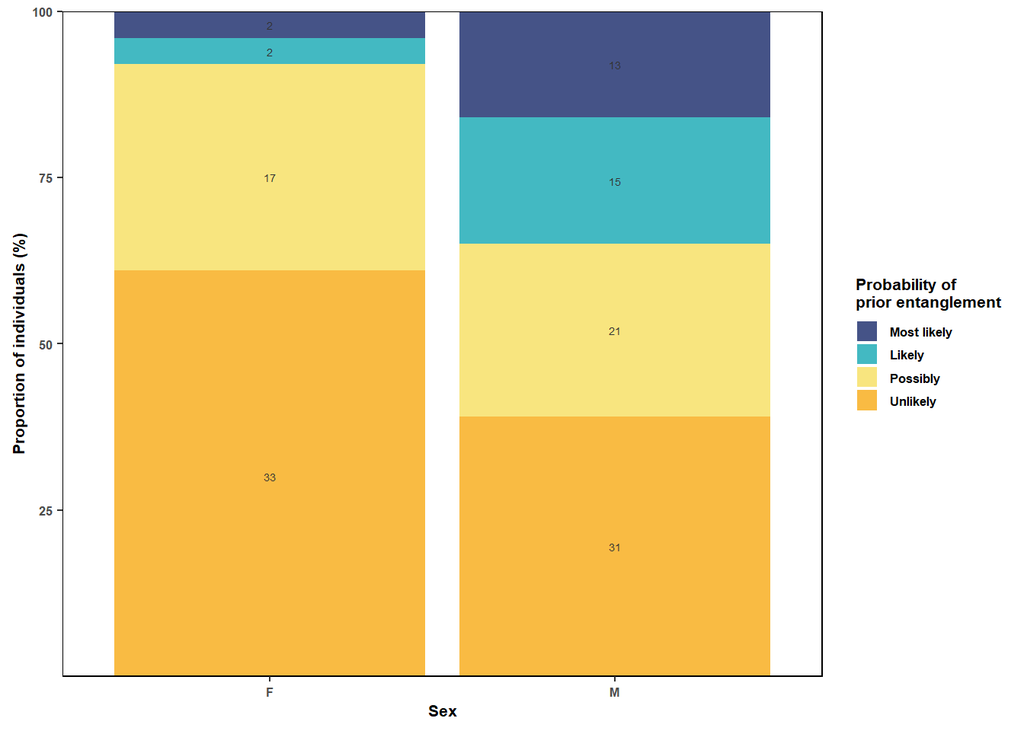

```r
g <- ggplot(sex_df,
            aes(x=Sex, y=percent, fill=Entang)) +
  geom_bar(stat="identity", alpha = 0.8) +
  geom_text(data = sex_df, aes(x = Sex, y = nlab, label = n),
            col = "grey20", size = 1.8) +
  scale_fill_manual(name = "Probability of \nprior entanglement",
                    values =  pal_wall) +
  mon_theme +
  ylab("Proportion of individuals (%)") +
  xlab("Sex") &
  scale_y_continuous(expand = c(0,0),
                     breaks = c(25, 50, 75, 100), limits = c(0, 100)) &
  theme(legend.key.size = unit(0.4, "cm"),
        legend.title = element_text(size = 8))
g
```

```r
ggsave(g, file =  "./Outputs/Fig4.png", width = 90, height = 90, units = "mm", dpi = 600)
```

```r
# put together a dataframe of scores per individual with identified sex
sex_clm_df <- score_best_df %>%
  group_by(ID) %>%
  arrange(Entang_num, .by_group = T) %>%
  slice_head(n = 1) %>%
  ungroup() %>%
  mutate(w = ifelse(Entang_num <= 2, 4-Quality_num, 3)) %>%
  mutate(w = w / mean(w)) %>%
  filter(!is.na(Sex)) %>%
  mutate(Sex = as.factor(Sex),
         Entang_num = as.factor(Entang_num))

# ru cumulative link model
m_sex <- clm(Entang_num ~ Sex + Body_part,
                      weights = w,
                      data = sex_clm_df)

# assess effect of sex on categorical probability of prior entanglement
car::Anova(m_sex, type = "II")
```

```
## Analysis of Deviance Table (Type II tests)
##
## Response: Entang_num
##           Df  Chisq Pr(>Chisq)
## Sex        1 54.514  1.543e-13 ***
## Body_part  3 53.766  1.259e-11 ***
## ---
## Signif. codes:  0 '***' 0.001 '**' 0.01 '*' 0.05 '.' 0.1 ' ' 1
```

```r
summary(m_sex)
```

```
## formula: Entang_num ~ Sex + Body_part
## data:    sex_clm_df
##
##  link  threshold nobs     logLik  AIC    niter max.grad cond.H
##  logit flexible  130.6347 -131.86 277.72 5(0)  1.54e-09 3.2e+01
##
## Coefficients:
##                           Estimate Std. Error z value Pr(>|z|)
## SexM                       -0.8713     0.3621  -2.406  0.01612 *
## Body_partFluke              0.3349     0.4143   0.808  0.41888
## Body_partPerpendicular T.  -2.1787     0.5896  -3.695  0.00022 ***
## Body_partVentral T.        -1.5238     0.5495  -2.773  0.00555 **
## ---
## Signif. codes:  0 '***' 0.001 '**' 0.01 '*' 0.05 '.' 0.1 ' ' 1
##
## Threshold coefficients:
##     Estimate Std. Error z value
## 1|2  -3.5666     0.4831  -7.383
## 2|3  -2.6354     0.4150  -6.350
## 3|4  -0.7964     0.3319  -2.400
```

```r
# additional analysis of sex effect using the Robbins & Mattila approach
sex_perp_clm_df <- perp_best_df %>%
  group_by(ID) %>%
  arrange(Perp_Entang_num, .by_group = T) %>%
  slice_head(n = 1) %>%
  ungroup() %>%
  mutate(w = ifelse(Perp_Entang_num <= 2, 4-Quality_num, 3)) %>%
  mutate(w = w / mean(w)) %>%
  filter(!is.na(Sex)) %>%
  mutate(Sex = as.factor(Sex),
         Perp_Entang_num = as.factor(Perp_Entang_num))

# ru cumulative link model
m_sex_perp <- clm(Perp_Entang_num ~ Sex,
                      weights = w,
                      data = sex_perp_clm_df)

# check data
table(sex_perp_clm_df$Sex, sex_perp_clm_df$Perp_Entang_num)
```

```
##
##      1  2  3  4  5
##   F  0  0  1  9  3
##   M  3  6  5 13  0
```

```r
# assess effect of sex on categorical probability of prior entanglement
car::Anova(m_sex_perp, type = "II")
```

```
## Analysis of Deviance Table (Type II tests)
##
## Response: Perp_Entang_num
##     Df  Chisq Pr(>Chisq)
## Sex  1 18.163  2.028e-05 ***
## ---
## Signif. codes:  0 '***' 0.001 '**' 0.01 '*' 0.05 '.' 0.1 ' ' 1
```

```r
summary(m_sex_perp)
```

```
## formula: Perp_Entang_num ~ Sex
## data:    sex_perp_clm_df
##
##  link  threshold nobs    logLik AIC   niter max.grad cond.H
##  logit flexible  39.8546 -42.45 94.89 7(0)  2.51e-09 7.7e+01
##
## Coefficients:
##      Estimate Std. Error z value Pr(>|z|)
## SexM   -2.865      1.077   -2.66  0.00782 **
## ---
## Signif. codes:  0 '***' 0.001 '**' 0.01 '*' 0.05 '.' 0.1 ' ' 1
##
## Threshold coefficients:
##     Estimate Std. Error z value
## 1|2  -5.1271     1.2030  -4.262
## 2|3  -4.0039     1.0877  -3.681
## 3|4  -2.9706     1.0307  -2.882
## 4|5   1.3322     0.6459   2.062
```

# 6 Simulation

## 6.1 Set parameters and scenarios

```r
#################################
### Scarring rate ###############
base_proportions <- perp_bestid_df %>%
  group_by(Perp_Entang, .drop = FALSE) %>%
  summarize(n = n()) %>%
  mutate(percent = round(n / sum(n)*100, 1)) %>%
  select(-c(n))

# prevalence of scars in the pop (based on Robbins et al scoring approach)
# between 2016 and 2023 - minimum Perp estimate for E4 and E3
(base_ent <- base_proportions[base_proportions$Perp_Entang %in% c("E4"), ]$percent/100 +
  base_proportions[base_proportions$Perp_Entang %in% c("E3"), ]$percent/100)
```

```
## [1] 0.273
```

```r
# baseline sample of the population entanglement status
dref <- perp_bestid_df %>%
  mutate(response = ifelse(Perp_Entang %in% c("E3", "E4"), 1, 0),
         year = "2023") %>%
  select(response, year)

#################################
### Resight rate parameter ######
# include a term for annual resighting rate
# reloading score_df that includes QUA4 photos for calculating resights
load("./Inputs/score_df.RData")
hb_or_df <- score_df %>%
  filter(Body_part == "Fluke underside") %>%
  filter(lat >= 41.9 & lat <= 46.3) %>%
  dplyr::select(ID, Date, Year) %>%
  # remove within season resights
  ddply(., .(ID, Year), function(d){d[1,]})

# number of sightings of photo-identified whales
a <- hb_or_df %>%
  filter(!(substr(ID, 1, 4) %in% c("MNOR", "NIMN"))) %>% nrow()
# number of unique IDs that were photo identified
b <- hb_or_df %>%
  filter(!(substr(ID, 1, 4) %in% c("MNOR", "NIMN"))) %>%
  summarize(unique_photoID = n_distinct(ID)) %>%
  pull(unique_photoID)

# resighting rate
resight_rate <- 100 - b * 100 / a
resight_rate
```

```
## [1] 11.43293
```

```r
# number of whales seen more than once
hb_or_df %>%
  ddply(., ~ID, function(d){data.frame(nb_sightings = nrow(d))}) %>%
  filter(nb_sightings > 1) %>%
  nrow()
```

```
## [1] 68
```

```r
####################################
### Set scenarios and conditions ###

scenarios_df <- tibble(sce_num = c(1:12),
       sce_ent = rep(c(rep("End abruptly", 3), rep("Continue at low prevalence", 3)), 2),
       sce_pop = rep(rep(c("Rapid growth", "Slow growth", "Carrying capacity"), 2), 2),
       pop_start_size = 1284 + 3185, # as per Caretta et al. 2023 - Curtis et al 2022 and Calambokidis & Barlow 2020
       pop_trend = rep(c(1.082, 1.041, 1), 4), # 0.082 is Calambokidis & Barlow 2020 estimate for california current whales. 8.2 % annually since 1989
       sce_surv = c(rep("Survival 0.95", 6), rep("Survival 0.97", 6)),
       survival = c(rep(0.95, 6), rep(0.97, 6)),
       pop_ref = list(dref),
       resight_rate = resight_rate,
       scar_rate = base_ent) %>%
  mutate(sce_ent = factor(sce_ent, levels = c("End abruptly", "Continue at low prevalence")),
         sce_pop = factor(sce_pop, levels = c("Rapid growth", "Slow growth", "Carrying capacity")))

scenarios_df
```

```
## # A tibble: 12 × 10
##    sce_num sce_ent    sce_pop pop_start_size pop_trend sce_surv survival pop_ref
##      <int> <fct>      <fct>            <dbl>     <dbl> <chr>       <dbl> <list>
##  1       1 End abrup… Rapid …           4469      1.08 Surviva…     0.95 <df>
##  2       2 End abrup… Slow g…           4469      1.04 Surviva…     0.95 <df>
##  3       3 End abrup… Carryi…           4469      1    Surviva…     0.95 <df>
##  4       4 Continue … Rapid …           4469      1.08 Surviva…     0.95 <df>
##  5       5 Continue … Slow g…           4469      1.04 Surviva…     0.95 <df>
##  6       6 Continue … Carryi…           4469      1    Surviva…     0.95 <df>
##  7       7 End abrup… Rapid …           4469      1.08 Surviva…     0.97 <df>
##  8       8 End abrup… Slow g…           4469      1.04 Surviva…     0.97 <df>
##  9       9 End abrup… Carryi…           4469      1    Surviva…     0.97 <df>
## 10      10 Continue … Rapid …           4469      1.08 Surviva…     0.97 <df>
## 11      11 Continue … Slow g…           4469      1.04 Surviva…     0.97 <df>
## 12      12 Continue … Carryi…           4469      1    Surviva…     0.97 <df>
## # ℹ 2 more variables: resight_rate <dbl>, scar_rate <dbl>
```

```r
##########################
##### Pop simulation  ####

# repeat the simulations three times, for the three different time period that are going to be tested: 2, 5 or 10 years after the change in entanglement rates
scenarios_df <- rbind(scenarios_df, scenarios_df, scenarios_df) %>%
  mutate(period = rep(c(2, 5, 10), each = nrow(scenarios_df)))

## simulating yearly proportion of scarred whales considering pop trend
scenarios_df <- scenarios_df %>%
  mutate(pop_simu = pmap(list(pop_start_size, pop_trend, scar_rate, sce_ent, sce_pop, pop_ref, survival, period), function(pop_start_size, pop_trend, scar_rate, sce_ent, sce_pop, pop_ref, survival, period){
    simu_df <- tibble(year = seq(2023,2023+period, 1), # if 2023 was the start date of the simulation, up to 2040
           pop_size = pop_start_size,
           nb_ent = round(pop_start_size * scar_rate, 0)) # nb of ind showing E3 and E4 scars when the starting pop size
   pop_of_year <- c(rep(0, pop_start_size - round(pop_start_size * scar_rate, 0)),
                    rep(1, round(pop_start_size * scar_rate, 0)))
    for (i in c(2:(period + 1))){
      ## a small portion of the population dies every year
      # randomly remove a % of the pop
      # nb of ind dying
      nb_dead <- floor((1-survival)*length(pop_of_year))
      pop_of_year <- pop_of_year[sample(c(1:length(pop_of_year)),
                            length(pop_of_year) - nb_dead, replace = F)]
      ## population grows every year, unless it is considered to be at carrying capacity (pop_trend = 1 in that case and the pop_size remains constant)
      # for every year, calculated pop size based on pop_trend and pop scenario
        simu_df$pop_size[i] <- round(simu_df$pop_size[i-1]
                               - (1-survival)*simu_df$pop_size[i-1]
                               + (log(pop_trend) + (1-survival))*simu_df$pop_size[i-1], 0)

      # for every year, calculated number of scarred individuals, considering assumptions on new entanglements occurring
      if(sce_ent == "End abruptly"){
        # no more entanglements so we complete the vector with as many zeros as they are new individuals in the population plus those that died and were "replaced"
        pop_of_year <- c(pop_of_year, rep(0,
                        nb_dead + (simu_df$pop_size[i]-simu_df$pop_size[i-1])))
        simu_df$nb_ent[i] <- length(pop_of_year[pop_of_year == 1]) # E4 and E3 scars do not fade but no more entanglements occur, a portion of the pop dies and is replaced by new individuals who are exempt from scars
      }
      if(sce_ent == "Continue at low prevalence"){
        # E4 and E3 scars do not fade but 5% of the pop keeps getting entangled every year
        # fill with zeros the new whales
        pop_of_year <- c(pop_of_year, rep(0,
                        nb_dead + (simu_df$pop_size[i]-simu_df$pop_size[i-1])))
        # but then randomly reentangle 5 % (and animals already showing scars can have new scars)
        new_entang <- sample(c(1:length(pop_of_year)), floor(0.05 * length(pop_of_year)), replace = F)
        pop_of_year[new_entang] <- 1
        simu_df$nb_ent[i] <- length(pop_of_year[pop_of_year == 1])
      }
    }

    simu_df <- simu_df %>%
        # calculate percent of whales with scars per year
        mutate(prop_scar = nb_ent / pop_size)
  }))

# plot trends
pop_simu_df <- scenarios_df %>%
  unnest(cols = pop_simu)

g_popsimu <- ggplot(subset(pop_simu_df, sce_ent == "End abruptly"), aes(x = year)) +
    geom_line(aes(y = pop_size), color = "grey30") +
    geom_line(aes(y = prop_scar*17000), color = "#0686BB", linetype = "21") +
    scale_linetype(name = "Entanglement scenario") +
    facet_grid(sce_surv~sce_pop) +
    scale_x_continuous(breaks = seq(2023,2040, 2),
                       labels = seq(2023,2040, 2) - 2023) +
    scale_y_continuous(name = "Population size",
      sec.axis = sec_axis(~./17000*100, breaks = seq(20, 100, 20),
                        name = "Scarring rate (%)")) +
    mon_theme +
    theme(
      #axis.text.x = element_text(angle = 45, vjust = 0.4),
      axis.title.y = element_text(color = "grey30"),
      axis.title.y.right = element_text(color = "#0686BB"),
      axis.text.y.right = element_text(color = "#0686BB"),
      legend.position = "bottom")
g_popsimu
ggsave(g_popsimu, file = "./Outputs/FigS3.png", width = 180, height = 140, units = "mm", dpi = 600)

###########################
### Sampling simulation ###

# let's admit that every year we sample from 5 to 250 individuals from the population
# based on max sample from 2018

scenarios_df <- scenarios_df %>%
  mutate(pop_simu = pmap(list(pop_simu), function(pop_simu){
  tibble(sample_size = seq(5, 250, 5)) %>%
    mutate(run_samples = map(sample_size, function(s){
      tibble(runs = c(1:1000)) %>%
        mutate(run_iterations = map(runs, function(i){
          pop_simu %>%
            mutate(binsample = pmap(list(w = nb_ent, x = pop_size, y = year), function(w, x, y){
              sample(c(rep(0, x - w), rep(1, w)), s, replace = FALSE)
            }))
        }))
    })) %>%
    unnest(cols = run_samples) %>%
    unnest(cols = run_iterations)
  }))

save(scenarios_df, file = "./Outputs/scenarios_df.RData")
```

## 6.2 Power analysis

```r
load("./Outputs/scenarios_df.RData")

#######################
### Power analysis ####

# cumulated samples from every year, remove resighted ind and compare to baseline reference to detect a change in scar prevalence
power_df <- scenarios_df %>%
  mutate(power = pmap(list(pop_simu, resight_rate, pop_ref, period),
                      function(pop_simu, resight_rate, pop_ref, period){
    ddply(pop_simu, .(sample_size, runs), function(d){
      d$sig <- NA
      # select all samples from 2024 up to year y
      cum_sample <- d %>%
        slice(1:(period+1)) %>%
        unnest(binsample)
      # remove a chunk of it already seen in prior years
      # number of individuals to keep (removing resights)
      nbkeep <- round((100-resight_rate) * nrow(cum_sample)/100, 0)
      # only keep these in the cumulative sample
      cum_sample <- cum_sample %>%
          slice_sample(n = nbkeep, replace = F)

      # put pop_ref and cum_sample under the same format and rbind them
      dd <- cum_sample %>%
        mutate(response = binsample) %>%
        select(response, year)

      # run linear regression and extract p-value and year coefficiant
      m <- glm(response ~ year, data = dd, family = binomial(link = "logit"))
      d$sig[[period + 1]] <- tidy(m)$p.value[2] <= .05
      d$est[period + 1] <- tidy(m)$estimate[2]
    return(d[c(1, (period + 1)), ])
  })
}))

# calculated number of runs in which a significant change in scarring rate was detected
power_sum_df <- power_df %>%
  mutate(power_sum = map(power, function(d){
    d %>%
      filter(!is.na(sig)) %>%
      mutate(sample_size = as.factor(sample_size),
         period = year - 2023,
         year = as.factor(year)) %>%
      group_by(sample_size, period, .drop = FALSE) %>%
      summarize(power_level = mean(sig, na.rm = T)*100,
                power_se = sd(sig, na.rm = T)/sqrt(100),
                estimate_coeff = mean(est, na.rm = T)) %>%
      mutate(power90 = ifelse(power_level >= 90, 1, 0),
             power80 = ifelse(power_level >= 80, 1, 0))
  }))

save(power_sum_df, file = "./Outputs/power_sum_df.RData")
```

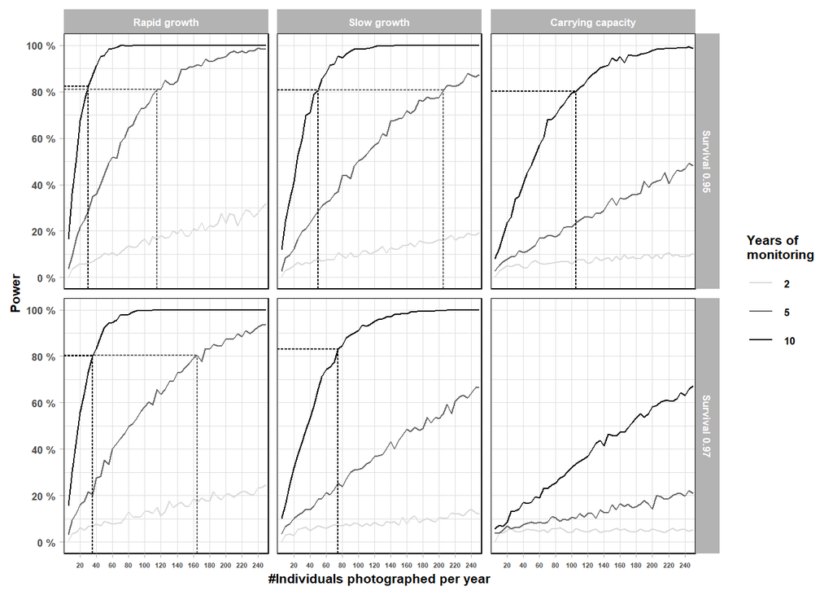

```r
load("./Outputs/power_sum_df.RData")

# extract the year at which 80 % power was reached for 30, 100 and 200 samples per year
ltb <- power_sum_df %>%
  select(-period) %>%
  unnest(cols = power_sum) %>%
  filter(power80 == 1) %>%
  group_by(sce_ent, sce_surv, sce_pop, period) %>%
  arrange(power_level, sample_size, .by_group = T) %>%
  slice_head(n = 1) %>%
  ungroup() %>%
  mutate(period = as.factor(period))

# unnest the power analysis data to produce a plot
ptb <- power_sum_df %>%
  select(-period) %>%
  unnest(cols = power_sum) %>%
  arrange(sce_ent, sce_surv, sce_pop, sample_size)%>%
  mutate(period = as.factor(period))

rm(power_sum_df)

# graphical representation with sample size as x axis
# focus on scenario where entanglement equal zero at start of the simulation
g <- ggplot() +
  geom_line(data = subset(ptb, sce_ent == "End abruptly"),
            aes(sample_size, power_level,
                group = period,
                color = period), linewidth = 0.5) +
  geom_segment(data = subset(ltb, sce_ent == "End abruptly"),
               aes(x = sample_size, xend = sample_size,
               y = -5, yend = power_level,
               color = period),
               linetype = "21", alpha = 1, linewidth = 0.4) +
  geom_segment(data = subset(ltb, sce_ent == "End abruptly"),
               aes(x = 0, xend = sample_size,
               y = power_level, yend = power_level,
               color = period),
               linetype = "21", alpha = 1, linewidth = 0.4) +
  theme_light() +
  mon_theme +
  facet_grid(sce_surv ~ sce_pop) +
  scale_x_discrete(name = "#Individuals photographed per year",
                   breaks = seq(0, 250, 20)) +
  scale_y_continuous("Power", limits = c(-5, 105),
                     breaks = c(0, 20, 40, 60, 80, 100),
                     labels = paste(c(0, 20, 40, 60, 80, 100), "%"),
                     expand = c(0,0)) +
  scale_color_manual(name = "Years of \nmonitoring", values = c("grey85", "grey40", "black")) +
  theme(axis.text.x = element_text(size = 4))

ggsave(g, file = "./Outputs/Fig5.png", width = 180, height = 110, units = "mm", dpi = 600)
g
```